# GR5242 Final Project - No.3 - Feature visualization

## Group Member: Yitong Hu (yh2875)

## 1. Introduction

This project is for better understanding how neural network work by doing feature visualization. To be more specific, I would explore the following questions during the project, what particular features various layers represent, given parameters of a trained model,what input image would drive a particular unit/filter/layer’s activation the most, and try different optimization method so as to make the images more recognizable.

### About the team

I'm in a group of myself. My original group was a team of four, and then separated due to my personal affairs. My previous teammates all agreed with that and I stated the detail in the email to TA Wenda Zhou. We only share the start point part, which is training a two layer CNN on MNIST,then we used the trained net and maximized the activation of different layers of the network to found the corresponding images, just code without interpretation or report part. We finished this part together and we are all willing to share that part after our splitting. More to be done like change to more datasets or add regularization term to optimize the feature visualization, those were the part after the split, we did not have discussion or share codes after our split and I did all by myself. Sorry for the inconvenience to evaluation due to our split.

### Introduce data I use

I mainly used two datasets in this project. One is MNIST, with 70000 * 28 * 28 * 1 as the input dimension and 70000 * 1 as the output dimension. The labels are number digit 0-9. Trainning sample size is 60,000 and testing sample size is 10,000. The other is SVHN, I used the train_32x32.mat, test_32x32.mat, its second format from the website<sup>[1]</sup>. It's cropped digits, 32-by-32 images centered around a single number. The input dimension of training set is (73257, 32, 32, 3), 73257 images, with 32 * 32 being width * height and 3 RGB channels. The output dimension is 73257 * 1. The input dimension of testing set is (26032, 32, 32, 3), 26032 images, with 32 * 32 being width * height and 3 RGB channels.

The motivation for choosing them is first, it's good dataset for starting with a lot of materials to refer to. Second, it's a consideration of CPU's computational difficulties, these two datasets are not that large and need lot of time to train model. Another benefit is that these two datasets are all labeled as number digits, so it's meaningful to compare them.

### The framework of this project

My whole work can divided into two parts:

First, I explored the feature visualization on MNIST dataset. This part includes my starting point which is training a 3 layer CNN(conv1 -> pool1 -> conv2 -> pool2 -> conv3 -> pool3 -> fc1 -> dropout -> fc2) based on MNIST dataset and maximizing the activation of different unit/filter/layer of the network to found the corresponding images. To optimize the feature visualization,my work includes adjusting the image initializing, tuning related parameters. To deal with the problem of getting images with high-frequency patterns for the higher layer, I tried adding regularization term and using Gaussian blur in order to make each layer more recognizable. Besides, I implement the interaction between neurons mentioned in Google's post about feature visualization<sup>[2]</sup>.Second, I tried on SVHN dataset using similar model(with some little change) and do the visualization and optimize it in the same way.

### Related work before coding

Before coding, my main work is focus on reading Google's post about feature visualization<sup>[2]</sup> and its citations. Besides reading the whole article talking about how to do the visualization, the direction we can explore, the problem we would meet as well as the solutions, I also read the 19 citation papers roughly.

In the paper *Visualizing Higher-Layer Features of a Deep Network*<sup>[3]</sup>, it mentioned maximizing the activation which is the core idea to do the feature visualization. Based on this idea, I made my goal clearly which is to find what input image would drive a particular unit/filter/layer’s activation the most. Another paper *Intriguing properties of neural networks* cited in the google post mentioned supplemental perspective, besides treat neuron as a unit to understand neural nets,in real life, combinations of neurons actually work together to represent images in neural networks<sup>[4]</sup>. This inspired me to see the interaction between neurons while visualizing.

Google post also mentioned when visualizing features by optimizing an image to make neurons ﬁre, the problem I would met is ending up with a kind of neural network optical illusion — an image full of noise and nonsensical high-frequency patterns that the network responds strongly to<sup>[2]</sup>. Several papers mentioned solutions which can be concluded into three main families of regularization options.

The first one is called Frequency penalization. The paper *Understanding deep image representations by inverting them* introduced some regularisers in its second section, it suggested to explicitly penalize variance between neighboring pixels to deal with high-frequency features<sup>[5]</sup>. Another paper *Deep neural networks are easily fooled: High confidence predictions for unrecognizable images* introduced several method based on frequency penalization, like adding regularization, using pseudo regularization(set some pixels to 0 or use decay) and blurring the image at each optimization step<sup>[6]</sup>. A html blog mentioned a way the improve the above method as using a bilateral ﬁlter, which preserves edges, instead of blurring, but just idea with no detailed formula or code here<sup>[7]</sup>. I learned principles of bilateral ﬁlter from the other paper as a image processing skill<sup>[8]</sup>.

The second one is Transformation robustness. The idea is easy to understand, during our trying to ﬁnd images activate the optimization target highly,we can change(jitter, rotate or scale) the image before applying the optimization step. In the google post, it mentioned this adjust maybe effective when combined with a more general regularizer for high-frequencies. Like in paper *Deep Inside Convolutional Networks: Visualising Image Classification Models and Saliency Maps*, it used image jittering, based on zeroing-out random parts of an image while doing the visualising<sup>[9]</sup>.Transformation robustness is more like a auxiliary trick to process the image, in order to optimize what we see as the result.

The last one is Learned priors whose idea is to learn a prior and jointly optimize for the prior along with your objective<sup>[10]</sup>. I gained a rough idea about its principle but have no idea about implement, no enough easy-to-implement instruction findings here.

### The challenge of the project

The challenge is to incorporate regularization, such as natural image priors, to generate optimized input that can be interpreted. By now, the academic understanding of the various regularization terms, however, is still limited and may result in unexpected outcomes. Also, in order to qualify its interpretability, we have to manually look at the output of each feature activation. Finally, the ideal training process requires tremendous computational power and the use of GPU which can be difficult to navigate.

**Tips: If you want to first have a quick review of the summary about this project, you can directly go to part 4 which is a summary.**

## 2. Experiment on MNIST

All the experiment in the following can be divided into two parts. First, the weights of the neural network are optimized by inputting images and their true classes to the network so as to improve the classification accuracy. Second, optimization is performed which finds the input image that maximizes a given feature or neuron inside the network. This finds an image that the network wants to find.

```python
from tensorflow.examples.tutorials.mnist import input_data
import tensorflow as tf
from matplotlib import pyplot as plt
import numpy as np
%matplotlib inline
import tempfile
import math
```

### 2.0 starting point (3 layer CNN + basic settings)

My starting point is training a 3 layer CNN(conv1 -> pool1 -> conv1 -> pool1 -> conv1 -> pool1 -> fc1 -> dropout -> fc2). My model largely referred to the model provided in the tensorflow tutorial<sup>[11]</sup>. While training, I choose 20000 steps to ensure a pretty good test accuracy which is 99.21%.

### Model training

```python
def weight_variable(shape):
    """weight_variable generates a weight variable of a given shape."""
    initial = tf.truncated_normal(shape, stddev=0.1)
    return tf.Variable(initial)
def bias_variable(shape):
    initial = tf.constant(0.1, shape=shape)
    return tf.Variable(initial)

def conv2d(x, W):
    return tf.nn.conv2d(x, W, strides=[1, 1, 1, 1], padding='SAME')

def max_pool_2x2(x):
    return tf.nn.max_pool(x, ksize=[1, 2, 2, 1],
                        strides=[1, 2, 2, 1], padding='SAME')
```

```python
def deepnn(x):

    with tf.name_scope('reshape'):
        x_image = tf.reshape(x, [-1, 28, 28, 1])

    with tf.name_scope('conv1'):
        W_conv1 = weight_variable([5, 5, 1, 32])
        b_conv1 = bias_variable([32])
        h_conv1 = tf.nn.relu(conv2d(x_image, W_conv1) + b_conv1)

    with tf.name_scope('pool1'):
        h_pool1 = max_pool_2x2(h_conv1)

    with tf.name_scope('conv2'):
        W_conv2 = weight_variable([5, 5, 32, 64])
        b_conv2 = bias_variable([64])
        h_conv2 = tf.nn.relu(conv2d(h_pool1, W_conv2) + b_conv2)

    with tf.name_scope('pool2'):
        h_pool2 = max_pool_2x2(h_conv2)

    with tf.name_scope('conv3'):
        W_conv3 = weight_variable([5, 5, 64, 64])
        b_conv3 = bias_variable([64])
        h_conv3 = tf.nn.relu(conv2d(h_pool2, W_conv3) + b_conv3)

    with tf.name_scope('pool3'):
        h_pool3 = max_pool_2x2(h_conv3)

    with tf.name_scope('fc1'):
        W_fc1 = weight_variable([4 * 4 * 64, 1024])
        b_fc1 = bias_variable([1024])

        h_pool3_flat = tf.reshape(h_pool3, [-1, 4*4*64])
        h_fc1 = tf.nn.relu(tf.matmul(h_pool3_flat, W_fc1) + b_fc1)

    with tf.name_scope('dropout'):
        keep_prob = tf.placeholder(tf.float32)
        h_fc1_drop = tf.nn.dropout(h_fc1, keep_prob)

    with tf.name_scope('fc2'):
        W_fc2 = weight_variable([1024, 10])
        b_fc2 = bias_variable([10])

        y_conv = tf.matmul(h_fc1_drop, W_fc2) + b_fc2
    return y_conv, keep_prob
```

```python
mnist = input_data.read_data_sets("MNIST_data/", one_hot=True)
x = tf.placeholder(tf.float32, [None, 784])
y_ = tf.placeholder(tf.float32, [None, 10])
y_conv, keep_prob = deepnn(x)

with tf.name_scope('loss'):
    cross_entropy = tf.nn.softmax_cross_entropy_with_logits(labels=y_,
                                                            logits=y_conv)
    cross_entropy = tf.reduce_mean(cross_entropy)

with tf.name_scope('adam_optimizer'):
    train_step = tf.train.AdamOptimizer(1e-4).minimize(cross_entropy)

with tf.name_scope('accuracy'):
    correct_prediction = tf.equal(tf.argmax(y_conv, 1), tf.argmax(y_, 1))
    correct_prediction = tf.cast(correct_prediction, tf.float32)
    accuracy = tf.reduce_mean(correct_prediction)

sess = tf.InteractiveSession()
sess.run(tf.global_variables_initializer())
for i in range(20000):
    batch = mnist.train.next_batch(50)
    if i % 1000 == 0:
        train_accuracy = accuracy.eval(feed_dict={
        x: batch[0], y_: batch[1], keep_prob: 1.0})
        #print('step %d, training accuracy %g' % (i, train_accuracy))
    train_step.run(feed_dict={x: batch[0], y_: batch[1], keep_prob: 0.5})
var = [v for v in tf.trainable_variables()]
par_values = [(v,sess.run(v)) for v in var]

#print('test accuracy %g' % accuracy.eval(feed_dict={x: mnist.test.images, y_: mnist.test.labels, keep_prob: 1.0}))
```

### What particular features various layers represent (Here, no activation maximization used!)

My first intuition is to visualize particular features various layers represent is the following. I used a certain test image with its original image looks as the following. I then separately chose the first 5 filters of each layer to visualize, in order to see what particular features various layers represent during the process of classifying number '0' and '2'.

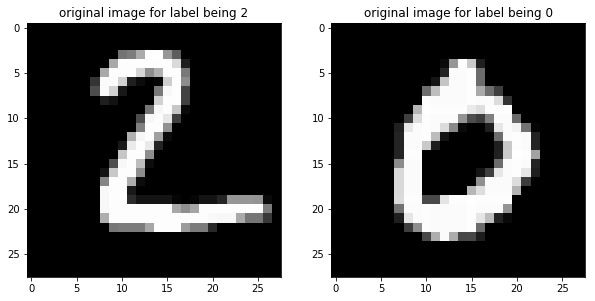

```python
plt.figure(1, figsize=(10,5))
n_columns = 2
n_rows = 1
imageToUse1 = mnist.test.images[1]
imageToUse2 = mnist.test.images[3]
plt.subplot(n_rows, n_columns, 1)
plt.title('original image for label being 2')
plt.imshow(np.reshape(imageToUse1,[28,28]), interpolation="nearest", cmap="gray")
plt.subplot(n_rows, n_columns, 2)
plt.title('original image for label being 0')
plt.imshow(np.reshape(imageToUse2,[28,28]), interpolation="nearest", cmap="gray")
```

The above are the original image of two arbitrary test image with label being '2' and '0'. The following three group of image shows the direct visualization for the activation of first, second and third layer. We can see the 'image'(actually it's the activation value) become more and more magnified and blurred, which is reasonable due to the convolution. The machine, the network can correctly classify the image with these unrecognizable pattern, but we can still not figure out what images the network wants to find. So we use other methods.

### 1st convolutional layer

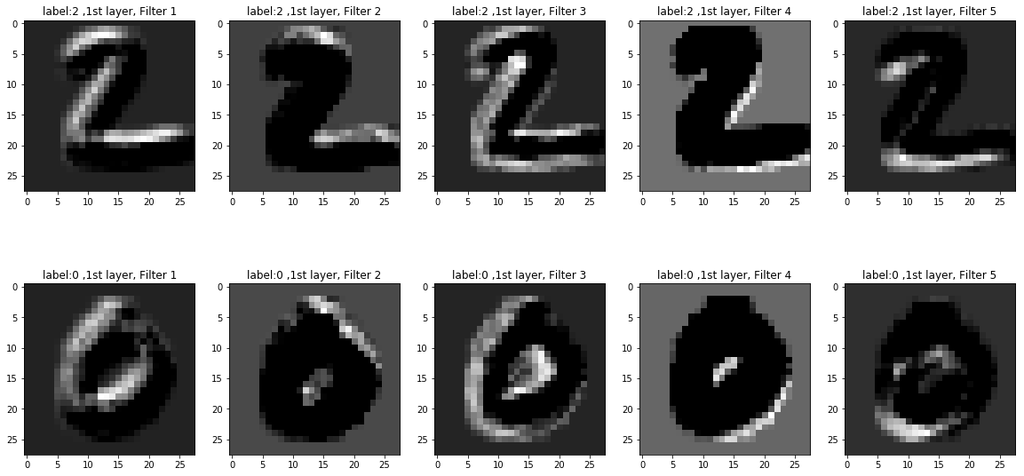

```python
h_conv1 = sess.graph.get_tensor_by_name('conv1_3/Relu:0')
plt.figure(1, figsize=(20,10))
n_columns = 5
n_rows = 2
for i in range(5):
    plt.subplot(n_rows, n_columns, i+1)
    plt.title('label:2 ,1st layer, Filter ' + str(i+1))
    plt.imshow(sess.run(h_conv1[0,:,:,i],feed_dict={
        x:np.reshape(mnist.test.images[1],[1,784]), keep_prob: 1.0}), interpolation="nearest", cmap="gray")
for i in range(5):
    plt.subplot(n_rows, n_columns, i+6)
    plt.title('label:0 ,1st layer, Filter ' + str(i+1))
    plt.imshow(sess.run(h_conv1[0,:,:,i],feed_dict={
        x:np.reshape(mnist.test.images[3],[1,784]), keep_prob: 1.0}), interpolation="nearest", cmap="gray")
```

### 2nd convolutional layer

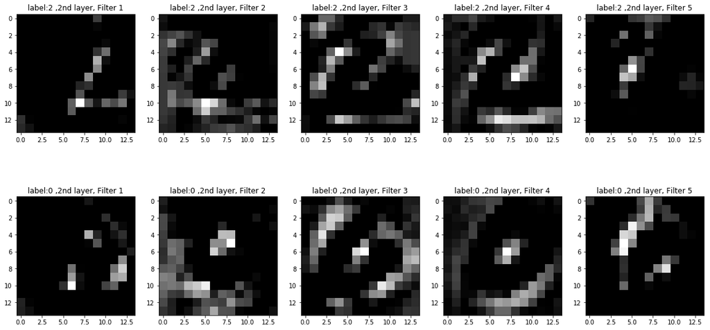

```python
h_conv2 = sess.graph.get_tensor_by_name('conv2_3/Relu:0')
plt.figure(1, figsize=(20,10))
n_columns = 5
n_rows = 2
for i in range(5):
    plt.subplot(n_rows, n_columns, i+1)
    plt.title('label:2 ,2nd layer, Filter ' + str(i+1))
    plt.imshow(sess.run(h_conv2[0,:,:,i],feed_dict={
        x:np.reshape(mnist.test.images[1],[1,784]), keep_prob: 1.0}), interpolation="nearest", cmap="gray")
for i in range(5):
    plt.subplot(n_rows, n_columns, i+6)
    plt.title('label:0 ,2nd layer, Filter ' + str(i+1))
    plt.imshow(sess.run(h_conv2[0,:,:,i],feed_dict={
        x:np.reshape(mnist.test.images[3],[1,784]), keep_prob: 1.0}), interpolation="nearest", cmap="gray")
```

### 3rd convolutional layer

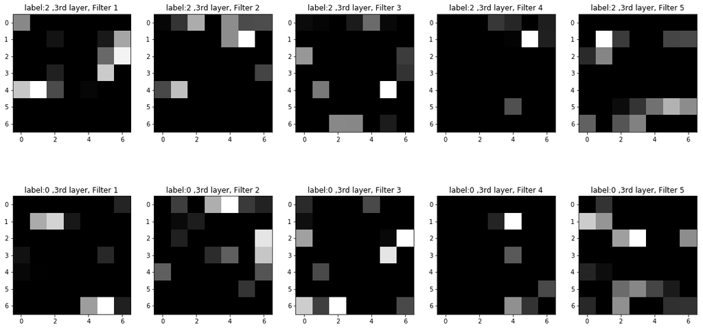

```python
h_conv3 = sess.graph.get_tensor_by_name('conv3_3/Relu:0')
plt.figure(1, figsize=(20,10))
n_columns = 5
n_rows = 2
for i in range(5):
    plt.subplot(n_rows, n_columns, i+1)
    plt.title('label:2 ,3rd layer, Filter ' + str(i+1))
    plt.imshow(sess.run(h_conv3[0,:,:,i],feed_dict={
        x:np.reshape(mnist.test.images[1],[1,784]), keep_prob: 1.0}), interpolation="nearest", cmap="gray")
for i in range(5):
    plt.subplot(n_rows, n_columns, i+6)
    plt.title('label:0 ,3rd layer, Filter ' + str(i+1))
    plt.imshow(sess.run(h_conv3[0,:,:,i],feed_dict={
        x:np.reshape(mnist.test.images[3],[1,784]), keep_prob: 1.0}), interpolation="nearest", cmap="gray")
```

### What input image would drive each layer’s activation the most

The second idea is inspired by the activation maximization method mentioned in a paper *Visualizing higher-layer features of a deep network* published in 2009<sup>[4]</sup>(the third citation of the google's post<sup>[1]</sup>). I used the trained net by saving all the parameters, then generated my initializing image by truncated normal and separately maximized the activation of different filters in each layer to found the corresponding images.

```python
import time
start = time.clock()
```

```python
## Rerun this piece of code would take about 10 hours.
## if needed, can change stepsize to be small

stepsize = 20000

with tf.Graph().as_default() as new_graph:

    x_image = tf.Variable(tf.truncated_normal((1,28,28,1),mean=0.5,stddev=0.1))

    #x_image_limit = tf.clip_by_value(x_image,0,1)

    x_min = tf.reduce_min(x_image)
    x_max = tf.reduce_max(x_image)
    x_image_limit = (x_image - x_min) / (x_max - x_min)

    with tf.name_scope('conv1'):
        W_conv1 = tf.constant(par_values[0][1])
        b_conv1 = tf.constant(par_values[1][1])
        h_conv1 = tf.nn.relu(conv2d(x_image_limit, W_conv1) + b_conv1)

    with tf.name_scope('pool1'):
        h_pool1 = max_pool_2x2(h_conv1)

    with tf.name_scope('conv2'):
        W_conv2 = tf.constant(par_values[2][1])
        b_conv2 = tf.constant(par_values[3][1])
        h_conv2 = tf.nn.relu(conv2d(h_pool1, W_conv2) + b_conv2)

    with tf.name_scope('pool2'):
        h_pool2 = max_pool_2x2(h_conv2)

    with tf.name_scope('conv3'):
        W_conv3 = tf.constant(par_values[4][1])
        b_conv3 = tf.constant(par_values[5][1])
        h_conv3 = tf.nn.relu(conv2d(h_pool2, W_conv3) + b_conv3)

    with tf.name_scope('pool3'):
        h_pool3 = max_pool_2x2(h_conv3)

    with tf.name_scope('fc1'):
        W_fc1 = tf.constant(par_values[6][1])
        b_fc1 = tf.constant(par_values[7][1])

        h_pool3_flat = tf.reshape(h_pool3, [-1, 4*4*64])
        h_fc1 = tf.nn.relu(tf.matmul(h_pool3_flat, W_fc1) + b_fc1)

    with tf.name_scope('fc2'):
        W_fc2 = tf.constant(par_values[8][1])
        b_fc2 = tf.constant(par_values[9][1])

        y_conv = tf.matmul(h_fc1, W_fc2) + b_fc2

    with tf.name_scope('activation'):
        filter_list1 = []
        filter_list2 = []
        filter_list3 = []
        filter_list4 = []
        for i in range(32):  ## 32 filters in total
            filter_list1.append(-tf.reduce_sum(h_conv1[:,:,:,i],[0,1,2])) #h_conv1 shape: 1 * 28 * 28 * 32
        for i in range(64):  ## 64 filters in total
            filter_list2.append(-tf.reduce_sum(h_conv2[:,:,:,i],[0,1,2])) #h_conv2 shape: 1 * 14 * 14 * 64
        for i in range(64):  ## 64 filters in total
            filter_list3.append(-tf.reduce_sum(h_conv3[:,:,:,i],[0,1,2])) #h_conv3 shape: 1 * 7 * 7 * 64
        for i in range(10):  ## 64 filters in total
            filter_list4.append(-y_conv[0,i])


    with tf.name_scope('optimizer'):
        train_step_list1 = []
        train_step_list2 = []
        train_step_list3 = []
        train_step_list4 = []
        for i in range(32):
            train_step_list1.append(tf.train.AdamOptimizer(0.001).minimize(filter_list1[i]))
        for i in range(64):
            train_step_list2.append(tf.train.AdamOptimizer(0.001).minimize(filter_list2[i]))
        for i in range(64):
            train_step_list3.append(tf.train.AdamOptimizer(0.001).minimize(filter_list3[i]))
        for i in range(10):
            train_step_list4.append(tf.train.AdamOptimizer(0.001).minimize(filter_list4[i]))

    with tf.Session() as sess:
        final_image_list1 = []
        final_image_list2 = []
        final_image_list3 = []
        final_image_list4 = []
        for j in range(32):
            sess.run(tf.global_variables_initializer())
            for i in range(stepsize):
                #if i%1000==0:
                #    print('layer1,filter %d,step %d, activation: %g' % (j,i, sess.run(filter_list1[j])))
                train_step_list1[j].run()
            final_image_list1.append(sess.run(x_image_limit))
        #print('layer1 image ready!')

        for j in range(64):
            sess.run(tf.global_variables_initializer())
            for i in range(stepsize):
                #if i%1000==0:
                #    print('layer2,filter %d,step %d, activation: %g' % (j,i, sess.run(filter_list2[j])))
                train_step_list2[j].run()
            final_image_list2.append(sess.run(x_image_limit))
        #print('layer2 image ready!')

        for j in range(64):
            sess.run(tf.global_variables_initializer())
            for i in range(stepsize):
                #if i%1000==0:
                #    print('layer3,filter %d,step %d, activation: %g' % (j,i, sess.run(filter_list3[j])))
                train_step_list3[j].run()
            final_image_list3.append(sess.run(x_image_limit))
        #print('layer3 image ready!')

        for j in range(10):
            sess.run(tf.global_variables_initializer())
            for i in range(stepsize):
                #if i%1000==0:
                #    print('layer4,filter %d,step %d, activation: %g' % (j,i, sess.run(filter_list4[j])))
                train_step_list4[j].run()
            final_image_list4.append(sess.run(x_image_limit))
        #print('layer4 image ready!')
```

```python
elapsed = (time.clock() - start)
print("Time used:",elapsed)
```

```
Time used: 38718.76506599999
```

For the iteration steps choice, I check our loss function with iteration steps increasing for 1st,2nd and 3rd layers while the optimizing process, as the following image shows. I found for whatever layers, after 20000 steps, the loss function just levels off, so I chose 20000 as my training steps to optimize the activation function.

[figure not shown]

The following are my results. In my network, there are 3 convolutional layers as well as the output which are what I want to visualize,with 32 filters used in the first convolutional layer, 64 filters used in the second convolutional layer and 64 filters used in the third convolutional layer.

### 1st convolutional layer

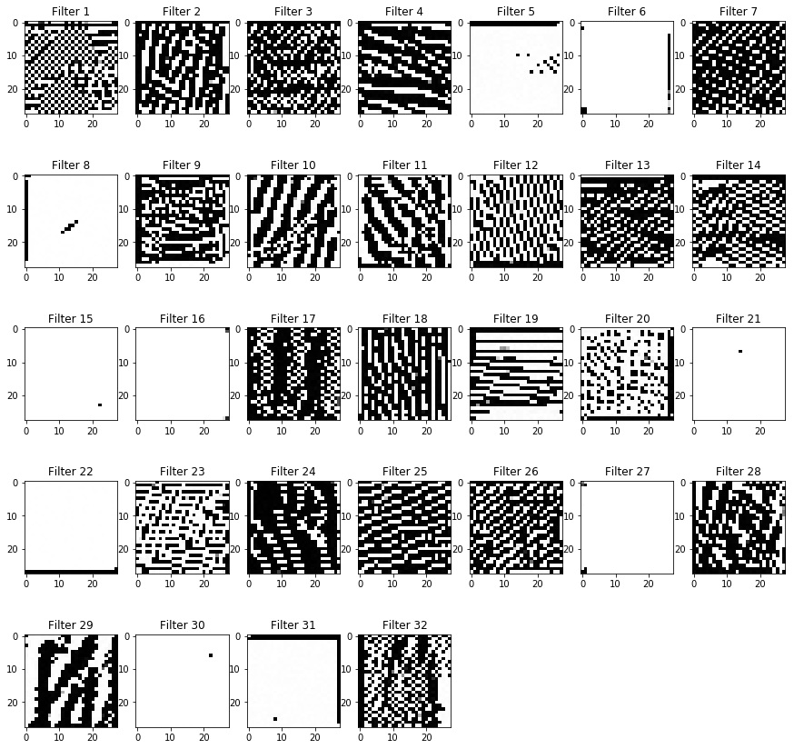

```python
plt.figure(1, figsize=(15,15))
n_columns = 7
n_rows = 5
for i in range(32):
    plt.subplot(n_rows, n_columns, i+1)
    plt.title('Filter ' + str(i+1))
    plt.imshow(final_image_list1[i].reshape(28,28),cmap='gray')
```

### 2nd convolutional layer

The following are the images that can maximally activated the filters in 2nd convolutional layer, and next part is 3rd convolutional layer,there are separately 64 filters for each layer. I did not see what I expect, no more complex texture founded but the noise pattern appeared in some of the filters.

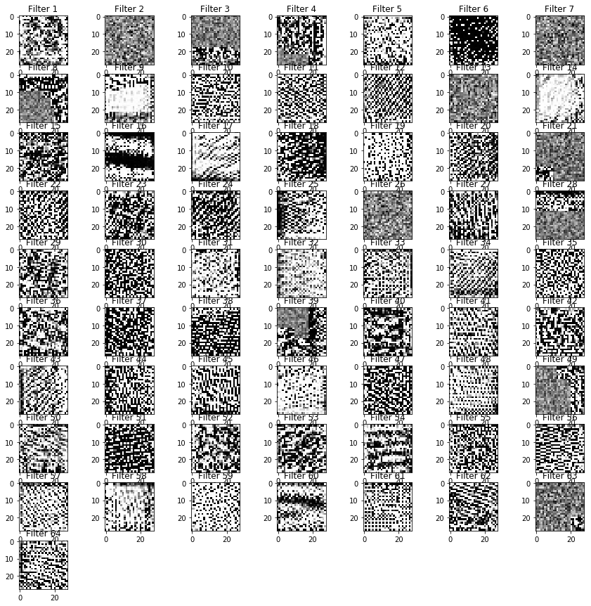

```python
plt.figure(1, figsize=(15,15))
n_columns = 7
n_rows = 10
for i in range(64):
    plt.subplot(n_rows, n_columns, i+1)
    plt.title('Filter ' + str(i+1))
    plt.imshow(final_image_list2[i].reshape(28,28),cmap='gray')
```

### 3rd convolutional layer

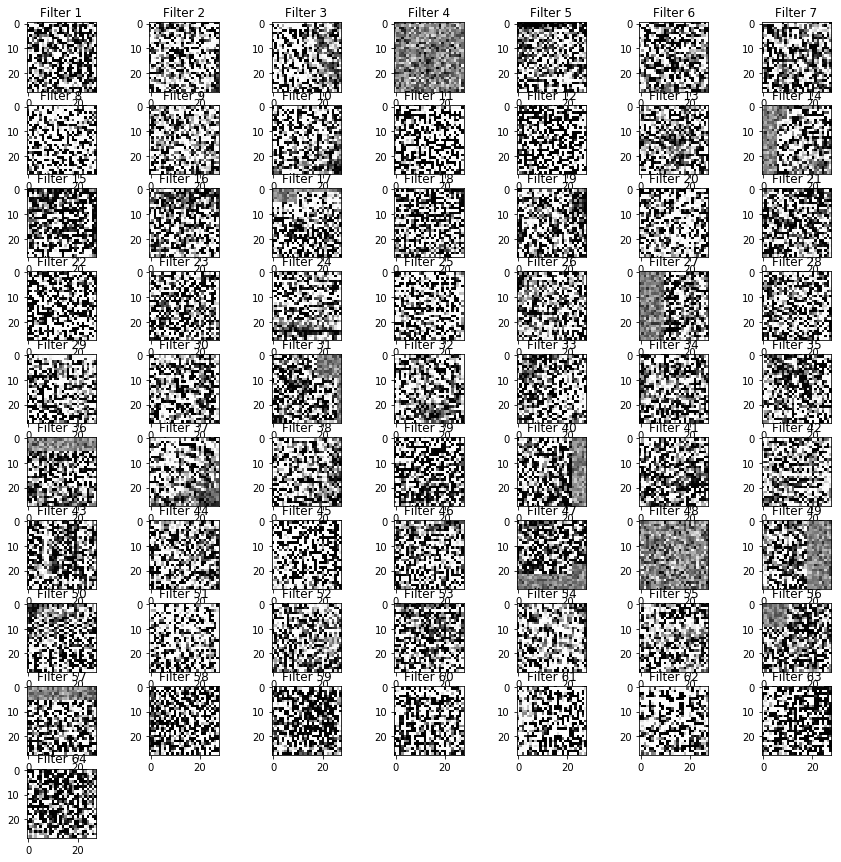

```python
plt.figure(1, figsize=(15,15))
n_columns = 7
n_rows = 10
for i in range(64):
    plt.subplot(n_rows, n_columns, i+1)
    plt.title('Filter ' + str(i+1))
    plt.imshow(final_image_list3[i].reshape(28,28),cmap='gray')
```

### Final output layer

The following are the images that can maximally activated the final output layer, I was supposed to observe the digit from 0 to 9, but I can hardly see. I guess it maybe due to the high frequency noise mentioned in the google post<sup>[1]</sup>. And in the next part, I would figure out some ways to optimize the feature visualization to make it more interpretable.

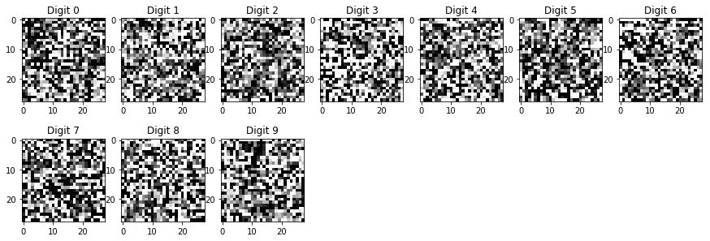

```python
plt.figure(1, figsize=(15,5))
n_columns = 7
n_rows = 2
for i in range(10):
    plt.subplot(n_rows, n_columns, i+1)
    plt.title('Digit ' + str(i))
    plt.imshow(final_image_list4[i].reshape(28,28),cmap='gray')
```

### 2.1 improving attempt 1 (Tunning the image initializer & learning rate)

In the above part, the image is initialized with small random values and is then iteratively updated for the given feature with regard to the image. I used 'truncated_normal' to generate a 28 * 28 initializing image with mean being 0.5 and sd being 0.1 as th input to my trained model. The idea were from looking through other's coding in similar project. Since our image here has no color, so those numbers need belong to (0,1). The previous scaling method is scale from 0 (minimum) to 1 (maximum).

Here I adjusted image initializer to expect a better performance in feature visualization. Since the large part of code does not need change, so here I just clarified the change in the code and attached the image I produced. Considering the computational difficulty, I would show the image corresponding to first 10 filter for each convolutional layer and 10 digits for the output layer.

#### 2.1.1 Tuning the standard deviation in truncated_normal

The original standard deviation used in truncated_normal is 0.1. Here I tried sd = {0.01,0.1,0.5,1} as well. The image patterns are similar with sd = 0.01 or 0.1, here I showed the better performance here with sd = 0.5.

We can see that, compared to the sd being 0.1,using 0.5 as standard deviation blur the patterns in the images for the following layers. For the 1st convolutional layer, the edges are still existed with different direction as well as different sizes. For the 2nd convolutional layer, a larger standard deviation seems to be better, since I can detect some texture here compared with the above settings which is just noise. The 3rd layer and last output layer are still unrecognizable.

[figure not shown]

[figure not shown]

[figure not shown]

[figure not shown]

#### 2.1.2 Change image scaling method from 'scale from 0 (minimum) to 1 (maximum)' to 'tf.clip_by_value(x_image,0,1)'

Another obvious way to modify the image is to ensure it is a valid image: all pixel values must be between 0 and 1 for MNIST image. So I tried changing image scaling method from 'scale from 0 (minimum) to 1 (maximum)' to 'tf.clip_by_value(x_image,0,1)', in order to keep it from 0 to 1. The patterns look similar to the above. But for the final layer, it's a little better than random noise pattern, while I could still not recognize the digits.There are some unfully trained flaw, so I think the previous method is better.

#### 1st convolutional layer

[figure not shown]

#### 2nd convolutional layer

[figure not shown]

#### 3rd convolutional layer

[figure not shown]

#### Final output layer

[figure not shown]

#### 2.1.3 Tuning the learning rate of the AdamOptimizer().

The original learning rate of the AdamOptimizer used in is 0.001. Here I tried sd = {0.0001,0.001,0.01,0.1} as well. The pattern with learning rate being 0.01 indicates a better performance. The images are similar to the above, without large improve, so I do not show here.

I learned from the google's post<sup>[1]</sup>, there is a part called The Enemy of Feature Visualization. It mentioned *'If you want to visualize features, you might just optimize an image to make neurons ﬁre. Unfortunately, this doesn’t really work. Instead, you end up with a kind of neural network optical illusion — an image full of noise and nonsensical high-frequency patterns that the network responds strongly to.'* That's the problem I met exactly. In the google's post, it also mentioned, there are three main families of regularization options to dealing with these high frequency noise.

So in the following parts, my main effort will put into implement some methods to deal with high frequency noise mentioned in that post and cited papers of that post.

### 2.2 improving attempt 2 (Adding regularization term during feature visualization)

I made my second improving attempt by adding regularization term. The parameters to adjust here are the lambda multipled by regularization term and L1 or L2 norm to choose. One paper mentioned using directly L1 norm with mean-subtracted images, it suggested lambda to be 1 so we start from setting lambda as 1 first and using L1-norm to see the effect.

```python
## Rerun this piece of code would take about 2.5 hours.
## if need rerun, can change stepsize to be small

import time
start = time.clock()

stepsize = 20000
learning_rate = 0.01
sd = 0.5
mylambda = 1
pnorm = 1

with tf.Graph().as_default() as new_graph:

    x_image = tf.Variable(tf.truncated_normal((1,28,28,1),mean=0.5,stddev=sd))

#    x_image_limit = tf.clip_by_value(x_image,0,1)

    x_min = tf.reduce_min(x_image)
    x_max = tf.reduce_max(x_image)
    x_image_limit = (x_image - x_min) / (x_max - x_min)

    with tf.name_scope('conv1'):
        W_conv1 = tf.constant(par_values[0][1])
        b_conv1 = tf.constant(par_values[1][1])
        h_conv1 = tf.nn.relu(conv2d(x_image_limit, W_conv1) + b_conv1)

    with tf.name_scope('pool1'):
        h_pool1 = max_pool_2x2(h_conv1)

    with tf.name_scope('conv2'):
        W_conv2 = tf.constant(par_values[2][1])
        b_conv2 = tf.constant(par_values[3][1])
        h_conv2 = tf.nn.relu(conv2d(h_pool1, W_conv2) + b_conv2)

    with tf.name_scope('pool2'):
        h_pool2 = max_pool_2x2(h_conv2)

    with tf.name_scope('conv3'):
        W_conv3 = tf.constant(par_values[4][1])
        b_conv3 = tf.constant(par_values[5][1])
        h_conv3 = tf.nn.relu(conv2d(h_pool2, W_conv3) + b_conv3)

    with tf.name_scope('pool3'):
        h_pool3 = max_pool_2x2(h_conv3)

    with tf.name_scope('fc1'):
        W_fc1 = tf.constant(par_values[6][1])
        b_fc1 = tf.constant(par_values[7][1])

        h_pool3_flat = tf.reshape(h_pool3, [-1, 4*4*64])
        h_fc1 = tf.nn.relu(tf.matmul(h_pool3_flat, W_fc1) + b_fc1)

    with tf.name_scope('fc2'):
        W_fc2 = tf.constant(par_values[8][1])
        b_fc2 = tf.constant(par_values[9][1])

        y_conv = tf.matmul(h_fc1, W_fc2) + b_fc2

    with tf.name_scope('activation'):
        filter_list1 = []
        filter_list2 = []
        filter_list3 = []
        filter_list4 = []
        regularization = tf.norm((x_image_limit),ord=pnorm)   ## L2 - norm
#         for i in range(10):  ## 32 filters in total
#             filter_list1.append(-tf.reduce_sum(h_conv1[:,:,:,i],[0,1,2])) #h_conv1 shape: 1 * 28 * 28 * 32
        for i in range(10):  ## 64 filters in total
            filter_list2.append(-tf.reduce_sum(h_conv2[:,:,:,i],[0,1,2])) #h_conv2 shape: 1 * 14 * 14 * 64
        for i in range(10):  ## 64 filters in total
            filter_list3.append(-tf.reduce_sum(h_conv3[:,:,:,i],[0,1,2])) #h_conv3 shape: 1 * 7 * 7 * 64
        for i in range(10):  ## 64 filters in total
            filter_list4.append(-y_conv[0,i])


    with tf.name_scope('optimizer'):
        train_step_list1 = []
        train_step_list2 = []
        train_step_list3 = []
        train_step_list4 = []
#         for i in range(10):
#             train_step_list1.append(tf.train.AdamOptimizer(learning_rate).minimize(filter_list1[i]+ mylambda * regularization ))
        for i in range(10):
            train_step_list2.append(tf.train.AdamOptimizer(learning_rate).minimize(filter_list2[i]+ mylambda * regularization))
        for i in range(10):
            train_step_list3.append(tf.train.AdamOptimizer(learning_rate).minimize(filter_list3[i]+ mylambda * regularization))
        for i in range(10):
            train_step_list4.append(tf.train.AdamOptimizer(learning_rate).minimize(filter_list4[i]+ mylambda * regularization))

    with tf.Session() as sess:
        final_image_list1 = []
        final_image_list2 = []
        final_image_list3 = []
        final_image_list4 = []
#         for j in range(10):
#             sess.run(tf.global_variables_initializer())
#             for i in range(stepsize):
#                 if i%1000==0:
#                     print('layer1,filter %d,step %d, activation: %g' % (j,i, sess.run(filter_list1[j])))
#                 train_step_list1[j].run()
#             final_image_list1.append(sess.run(x_image_limit))
#         print('layer1 image ready!')

        for j in range(10):
            sess.run(tf.global_variables_initializer())
            for i in range(stepsize):
                #if i%1000==0:
                #    print('layer2,filter %d,step %d, activation: %g' % (j,i, sess.run(filter_list2[j])))
                train_step_list2[j].run()
            final_image_list2.append(sess.run(x_image_limit))
        #print('layer2 image ready!')

        for j in range(10):
            sess.run(tf.global_variables_initializer())
            for i in range(stepsize):
                #if i%1000==0:
                #    print('layer3,filter %d,step %d, activation: %g' % (j,i, sess.run(filter_list3[j])))
                train_step_list3[j].run()
            final_image_list3.append(sess.run(x_image_limit))
        #print('layer3 image ready!')


        for j in range(10):
            sess.run(tf.global_variables_initializer())
            for i in range(stepsize):
                #if i%1000==0:
                #    print('output layer,filter %d,step %d, activation: %g' % (j,i, sess.run(filter_list4[j])))
                train_step_list4[j].run()
            final_image_list4.append(sess.run(x_image_limit))
        #print('output layer image ready!')
```

```python
elapsed = (time.clock() - start)
print("Time used:",elapsed)
```

```
Time used: 9150.720912999997
```

Since in the above part, we have already seen the edges pattern in the 1st convolutional layer, so I put my effort in adjusting and optimizing the high level layer to produce more interpretable images.

### 2nd convolutional layer (adding L1 regularization with lambda = 1)

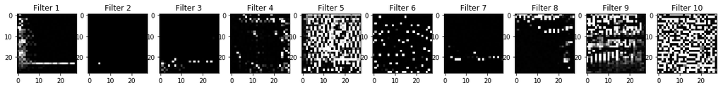

```python
plt.figure(1, figsize=(20,10))
n_columns = 10
n_rows = 1
for i in range(10):
    plt.subplot(n_rows, n_columns, i+1)
    plt.title('Filter ' + str(i+1))
    plt.imshow(final_image_list2[i].reshape(28,28),cmap='gray')
```

### 3rd convolutional layer (adding L1 regularization with lambda = 1)

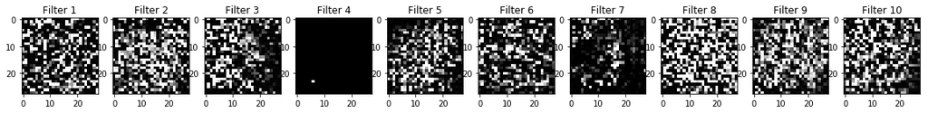

```python
plt.figure(1, figsize=(20,10))
n_columns = 10
n_rows = 1
for i in range(10):
    plt.subplot(n_rows, n_columns, i+1)
    plt.title('Filter ' + str(i+1))
    plt.imshow(final_image_list3[i].reshape(28,28),cmap='gray')
```

### Final output layer (adding L1 regularization with lambda = 1)

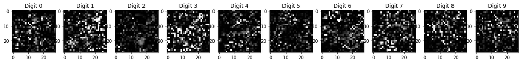

```python
plt.figure(1, figsize=(20,10))
n_columns = 10
n_rows = 1
for i in range(10):
    plt.subplot(n_rows, n_columns, i+1)
    plt.title('Digit ' + str(i))
    plt.imshow(final_image_list4[i].reshape(28,28),cmap='gray')
```

#### 2.2.1 Tuning lambda with L2 regularization

I tried lambda = {0.1,0.2,0.5,1} with L2 regularization, but did not get recognizable digits. Here is the final output layer images with L2-norm & lambda = 0.1, which is slightly better comparing with other lambda values, but it's worse than L1 regularization.

#### Final output layer with L2-norm & lambda = 0.1

[figure not shown]

#### 2.2.2 Tuning lambda with L1 regularization

We can see from the above, there are large area of black region indicating our over penalizing. So I changed lambda to be smaller, I tried lambda = {0.1,0.2,0.5,1}. Here I show the final layer output images to compare their performance ,we can see that when lambda = 0.1 and 0.2, there is rough sketch of the number digits, especially for digit 0,2,3,4 and 5, lambda being 0.2 seems to be better.

#### Final output layer with L1-norm & lambda = 0.1

[figure not shown]

#### Final output layer with L1-norm & lambda = 0.2

[figure not shown]

Above all, we can see from this part, some images can somewhat resemble the hand-written digits. But the other images are often impossible to recognize and it is hard to understand why the neural network thinks these are the optimal input images for those digits.

We found L1 regularization is better, which is reasonable and intuitive when considering about L1's principle. Since L1 is used to penalize by encouraging sparsity. While for MNIST which have no RGB colors, the image data naturally has a lot of zero displaying black. So the effect of L1 would result in more natural image, which is what we want. Therefore, L1 has a better effect on MNIST dataset for penalizing is reasonable.

### 2.3 improving attempt 3 (Modify image after each optimization: Decay & gaussian blur)

#### 2.3.1 Gaussian blur

The Gaussian blur is a type of image-blurring filter that uses a Gaussian function (which also expresses the normal distribution in statistics) for calculating the transformation to apply to each pixel in the image<sup>[12]</sup>.I referred one paper using gaussian blur with radius 0.3 after every gradient step for getting more recognizable images<sup>[6]</sup>. It was implemented by setting the gaussian kernel's radius, and using Gaussian Kernel Calculator<sup>[13]</sup> to get those weights of the kernel. Here, I also introduce a parameters called blurstep, which indicates blurring every other certain steps rather than every step The framework is still similar to the previous one, the code mainly changed is marked as following.

```python
stepsize = 20000
sd = 0.1
mylambda = 0.2
learningrate = 0.01
pnorm = 1
blurstep = 8

with tf.Graph().as_default() as new_graph:

    x_image = tf.Variable(tf.truncated_normal((1,28,28,1),mean=0.5,stddev=sd))

    x_min = tf.reduce_min(x_image)
    x_max = tf.reduce_max(x_image)
    x_image_limit = (x_image - x_min) / (x_max - x_min)

    ####################   code changed   ###################

    W_blur_array = np.array([
         [0.002284,0.043222,0.002284],  ## radiues 0.3
         [0.043222,0.817976,0.043222],
         [0.002284,0.043222,0.002284]
    ])
    W_blur = tf.reshape(tf.constant(W_blur_array,dtype=tf.float32),[3,3,1,1])
    x_blur = tf.nn.conv2d(x_image_limit, W_blur, strides=[1, 1, 1, 1], padding='SAME')

    ########################################################

    blur = tf.placeholder(tf.float32,[1,28,28,1])

    with tf.name_scope('conv1'):
        W_conv1 = tf.constant(par_values[0][1])
        b_conv1 = tf.constant(par_values[1][1])
        h_conv1 = tf.nn.relu(conv2d(blur*x_blur+(1-blur)*x_image_limit, W_conv1) + b_conv1)

    with tf.name_scope('pool1'):
        h_pool1 = max_pool_2x2(h_conv1)

    with tf.name_scope('conv2'):
        W_conv2 = tf.constant(par_values[2][1])
        b_conv2 = tf.constant(par_values[3][1])
        h_conv2 = tf.nn.relu(conv2d(h_pool1, W_conv2) + b_conv2)

    with tf.name_scope('pool2'):
        h_pool2 = max_pool_2x2(h_conv2)

    with tf.name_scope('conv3'):
        W_conv3 = tf.constant(par_values[4][1])
        b_conv3 = tf.constant(par_values[5][1])
        h_conv3 = tf.nn.relu(conv2d(h_pool2, W_conv3) + b_conv3)

    with tf.name_scope('pool3'):
        h_pool3 = max_pool_2x2(h_conv3)

    with tf.name_scope('fc1'):
        W_fc1 = tf.constant(par_values[6][1])
        b_fc1 = tf.constant(par_values[7][1])

        h_pool3_flat = tf.reshape(h_pool3, [-1, 4*4*64])
        h_fc1 = tf.nn.relu(tf.matmul(h_pool3_flat, W_fc1) + b_fc1)

    with tf.name_scope('fc2'):
        W_fc2 = tf.constant(par_values[8][1])
        b_fc2 = tf.constant(par_values[9][1])

        y_conv = tf.matmul(h_fc1, W_fc2) + b_fc2

    with tf.name_scope('activation'):
        filter_list1 = []
        filter_list2 = []
        filter_list3 = []
        filter_list4 = []
        regularization = tf.norm((x_image_limit
                                 # -tf.reduce_mean(x_image_limit,0)
                                 ),ord=pnorm)
        for i in range(10):  ## 32 filters in total
            filter_list1.append(-tf.reduce_sum(h_conv1[:,:,:,i],[0,1,2])) #h_conv1 shape: 1 * 28 * 28 * 32
        for i in range(10):  ## 64 filters in total
            filter_list2.append(-tf.reduce_sum(h_conv2[:,:,:,i],[0,1,2])) #h_conv2 shape: 1 * 14 * 14 * 64
        for i in range(10):  ## 64 filters in total
            filter_list3.append(-tf.reduce_sum(h_conv3[:,:,:,i],[0,1,2])) #h_conv3 shape: 1 * 7 * 7 * 64
        for i in range(10):
            filter_list4.append(-y_conv[0,i])


    with tf.name_scope('optimizer'):
        train_step_list1 = []
        train_step_list2 = []
        train_step_list3 = []
        train_step_list4 = []
        for i in range(10):
             train_step_list1.append(tf.train.AdamOptimizer(learningrate).minimize(filter_list1[i]+ mylambda * regularization ))
        for i in range(10):
            train_step_list2.append(tf.train.AdamOptimizer(learningrate).minimize(filter_list2[i]+ mylambda * regularization))
        for i in range(10):
            train_step_list3.append(tf.train.AdamOptimizer(learningrate).minimize(filter_list3[i]+ mylambda * regularization))
        for i in range(10):
            train_step_list4.append(tf.train.AdamOptimizer(learningrate).minimize(filter_list4[i]+ mylambda * regularization))


    with tf.Session() as sess:
        final_image_list1 = []
        final_image_list2 = []
        final_image_list3 = []
        final_image_list4 = []
#         for j in range(5):
#             sess.run(tf.global_variables_initializer())
#             for i in range(stepsize):
#                 if i%1000==0:
#                     print('layer1,filter %d,step %d, activation: %g' % (j,i, sess.run(filter_list1[j])))
#                 train_step_list1[j].run()
#             final_image_list1.append(sess.run(x_image_limit))
#         print('layer1 image ready!')

#         for j in range(5):
#             sess.run(tf.global_variables_initializer())
#             for i in range(stepsize):
#                 if i%1000==0:
#                     print('layer2,filter %d,step %d, activation: %g' % (j,i, sess.run(filter_list2[j])))
#                 train_step_list2[j].run()
#             final_image_list2.append(sess.run(x_image_limit))
#         print('layer2 image ready!')

#         for j in range(5):
#             sess.run(tf.global_variables_initializer())
#             for i in range(stepsize):
#                 if i%1000==0:
#                     print('layer3,filter %d,step %d, activation: %g' % (j,i, sess.run(filter_list3[j])))
#                 train_step_list3[j].run()
#             final_image_list3.append(sess.run(x_image_limit))
#         print('layer3 image ready!')

        for j in range(10):
            sess.run(tf.global_variables_initializer())
            for i in range(stepsize):
                if i%blurstep==0:
                     train_step_list4[j].run(feed_dict={blur:np.ones(shape=[1,28,28,1])})
                else:
                    train_step_list4[j].run(feed_dict={blur:np.zeros(shape=[1,28,28,1])})
                #if i%1000==0:
                #    print('layer4,filter %d,step %d, activation: %g' % (j,i, sess.run(filter_list4[j],feed_dict={blur:np.ones(shape=[1,28,28,1])})))
            final_image_list4.append(sess.run(x_image_limit,feed_dict={blur:np.ones(shape=[1,28,28,1])}))
        #print('layer4 image ready!')
```

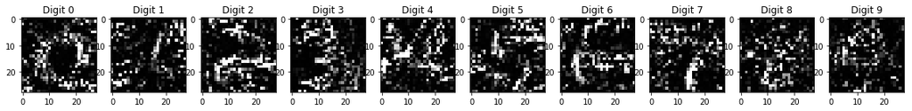

```python
plt.figure(1, figsize=(20,10))
n_columns = 10
n_rows = 1
for i in range(10):
    plt.subplot(n_rows, n_columns, i+1)
    plt.title('Digit ' + str(i))
    plt.imshow(final_image_list4[i].reshape(28,28),cmap='gray')
```

I tried gaussian radius with radius being {0.1,0.3,0.5,0.7} and blurstep being {1,2,4,6,8,10}. According to above,it shows a relatively better visualzation with gaussian radius being 0.3 and blurstep being 8. We can see that comparing with the images that maximumly activate the final output layer without gaussian radius (with other settings kept the same), the above images are more recognizable for some digits, like '0' and '7'.

#### 2.3.2 Decay

Decay is a more simple regularization ,which is to make the image closer to the mean at each step. Here we only need add one line code,`'x_image_limit = x_image_limit \* decay_rate'` to implement. The parameter 'decay_rate' represent the degree of decay. According to others' code, this value is usually very low, around 0.9999, but it really depends on the strength of the learning rate, and should be tuned along with learning rate.

Here we tried decay_rate = {0.9,0.99,0.999,0.9999}, but find no distinct improvement. I think it's reasonable considering its principle. Since decay is to avoid bright pixels with very high values in red, green or blue, it maybe useful in colored image rather than here.

#### Final output layer with decay rate being 0.9 (with other settings kept the same)

[figure not shown]

#### Final output layer with decay rate being 0.99 (with other settings kept the same)

[figure not shown]

#### Final output layer with decay rate being 0.999 (with other settings kept the same)

[figure not shown]

#### Final output layer with decay rate being 0.9999 (with other settings kept the same)

[figure not shown]

### 2.4 improving attempt 4 (Avoid local optimum)

Since there are some digits that are recognizable while others are not. I'm thinking about it is possible that the optimization has simply become stuck in a local optimum. So for the images that are unclear,I ran the optimization for each of those digits, to see if it produces more clear input images, but it seems not, so no better images shown.

### 2.5 exploring interaction between neurons

As the google post suggested,besides individual neuron as a way to understand neural nets, we can also explore the combinations of neurons working together to represent images in neural networks. Individual neurons are the basis directions of activation space, and it is not clear that these should be any more special than any other direction. So here we tried exploring interaction between filters(neurons).

```python
stepsize = 20000
sd = 0.1
mylambda = 0.2
learningrate = 0.01
pnorm = 1

with tf.Graph().as_default() as new_graph:

    x_image = tf.Variable(tf.truncated_normal((1,28,28,1),mean=0.5,stddev=sd))

    x_min = tf.reduce_min(x_image)
    x_max = tf.reduce_max(x_image)
    x_image_limit = (x_image - x_min) / (x_max - x_min)

    ####################   code changed   ###################

#     W_blur_array = np.array([
#          [0.002284,0.043222,0.002284],  ## radiues 0.3
#          [0.043222,0.817976,0.043222],
#          [0.002284,0.043222,0.002284]
#     ])
#     W_blur = tf.reshape(tf.constant(W_blur_array,dtype=tf.float32),[3,3,1,1])
#     x_blur = tf.nn.conv2d(x_image_limit, W_blur, strides=[1, 1, 1, 1], padding='SAME')

    ########################################################

    blur = tf.placeholder(tf.float32,[1,28,28,1])

    with tf.name_scope('conv1'):
        W_conv1 = tf.constant(par_values[0][1])
        b_conv1 = tf.constant(par_values[1][1])
        #h_conv1 = tf.nn.relu(conv2d(blur*x_blur+(1-blur)*x_image_limit, W_conv1) + b_conv1)
        h_conv1 = tf.nn.relu(conv2d(x_image_limit, W_conv1) + b_conv1)

    with tf.name_scope('pool1'):
        h_pool1 = max_pool_2x2(h_conv1)

    with tf.name_scope('conv2'):
        W_conv2 = tf.constant(par_values[2][1])
        b_conv2 = tf.constant(par_values[3][1])
        h_conv2 = tf.nn.relu(conv2d(h_pool1, W_conv2) + b_conv2)

    with tf.name_scope('pool2'):
        h_pool2 = max_pool_2x2(h_conv2)

    with tf.name_scope('conv3'):
        W_conv3 = tf.constant(par_values[4][1])
        b_conv3 = tf.constant(par_values[5][1])
        h_conv3 = tf.nn.relu(conv2d(h_pool2, W_conv3) + b_conv3)

    with tf.name_scope('pool3'):
        h_pool3 = max_pool_2x2(h_conv3)

    with tf.name_scope('fc1'):
        W_fc1 = tf.constant(par_values[6][1])
        b_fc1 = tf.constant(par_values[7][1])

        h_pool3_flat = tf.reshape(h_pool3, [-1, 4*4*64])
        h_fc1 = tf.nn.relu(tf.matmul(h_pool3_flat, W_fc1) + b_fc1)

    with tf.name_scope('fc2'):
        W_fc2 = tf.constant(par_values[8][1])
        b_fc2 = tf.constant(par_values[9][1])

        y_conv = tf.matmul(h_fc1, W_fc2) + b_fc2

    with tf.name_scope('activation'):
        filter_list1 = []
        filter_list2 = []
        filter_list3 = []
        filter_list4 = []
        regularization = tf.norm((x_image_limit
                                 # -tf.reduce_mean(x_image_limit,0)
                                 ),ord=pnorm)
        for i in range(32):  ## 32 filters in total
            filter_list1.append(-tf.reduce_sum(h_conv1[:,:,:,i],[0,1,2])) #h_conv1 shape: 1 * 28 * 28 * 32

    with tf.name_scope('optimizer'):
        train_step_list1 = []
        train_step_list2 = []
        train_step_list3 = []
        train_step_list4 = []
        for i in range(32):
             train_step_list1.append(tf.train.AdamOptimizer(learningrate).minimize(filter_list1[i]+ mylambda * regularization ))

    with tf.Session() as sess:
        final_image_list1 = []
        for j in range(32):
            sess.run(tf.global_variables_initializer())
            for i in range(stepsize):
                #if i%1000==0:
                #    print('layer1,filter %d,step %d, activation: %g' % (j,i, sess.run(filter_list1[j])))
                train_step_list1[j].run()
            final_image_list1.append(sess.run(x_image_limit))
        #print('layer1 image ready!')
```

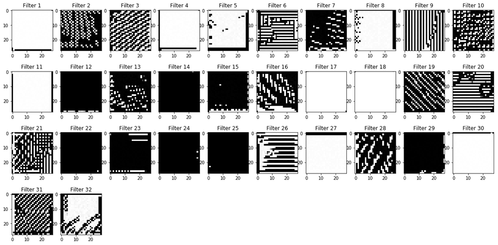

```python
plt.figure(1, figsize=(20,10))
n_columns = 10
n_rows = 4
for i in range(32):
    plt.subplot(n_rows, n_columns, i+1)
    plt.title('Filter ' + str(i+1))
    plt.imshow(final_image_list1[i].reshape(28,28),cmap='gray')
```

```python
stepsize = 20000
sd = 0.1
mylambda = 0.2
learningrate = 0.01
pnorm = 1

with tf.Graph().as_default() as new_graph:
    # Create the model

    x_image = tf.Variable(tf.truncated_normal((1,28,28,1),mean=0.5,stddev=sd))
    x_min = tf.reduce_min(x_image)
    x_max = tf.reduce_max(x_image)
    x_image_limit = (x_image - x_min) / (x_max - x_min)


    with tf.name_scope('conv1'):
        W_conv1 = tf.constant(par_values[0][1])
        b_conv1 = tf.constant(par_values[1][1])
        h_conv1 = tf.nn.relu(conv2d(x_image_limit, W_conv1) + b_conv1)

    with tf.name_scope('pool1'):
        h_pool1 = max_pool_2x2(h_conv1)

    with tf.name_scope('conv2'):
        W_conv2 = tf.constant(par_values[2][1])
        b_conv2 = tf.constant(par_values[3][1])
        h_conv2 = tf.nn.relu(conv2d(h_pool1, W_conv2) + b_conv2)

    with tf.name_scope('pool2'):
        h_pool2 = max_pool_2x2(h_conv2)

    with tf.name_scope('conv3'):
        W_conv3 = tf.constant(par_values[4][1])
        b_conv3 = tf.constant(par_values[5][1])
        h_conv3 = tf.nn.relu(conv2d(h_pool2, W_conv3) + b_conv3)

    with tf.name_scope('pool3'):
        h_pool3 = max_pool_2x2(h_conv3) ##  h_pool3 : 1 * 4 * 4 * 64


    with tf.name_scope('fc1'):
        W_fc1 = tf.constant(par_values[6][1])
        b_fc1 = tf.constant(par_values[7][1])

        h_pool3_flat = tf.reshape(h_pool3, [-1, 4*4*64])
        h_fc1 = tf.nn.relu(tf.matmul(h_pool3_flat, W_fc1) + b_fc1)

    with tf.name_scope('fc2'):
        W_fc2 = tf.constant(par_values[8][1])
        b_fc2 = tf.constant(par_values[9][1])

        y_conv = tf.matmul(h_fc1, W_fc2) + b_fc2

    with tf.name_scope('activation'):

        regularization = tf.norm((x_image_limit),ord=pnorm)
        filter_added = []
        filter_added.append(-(tf.reduce_sum(h_conv1[:,:,:,5],[0,1,2])+tf.reduce_sum(h_conv1[:,:,:,8],[0,1,2])))
        filter_added.append(-(tf.reduce_sum(h_conv1[:,:,:,2],[0,1,2])+tf.reduce_sum(h_conv1[:,:,:,18],[0,1,2])))
        filter_added.append(-(tf.reduce_sum(h_conv1[:,:,:,12],[0,1,2])+tf.reduce_sum(h_conv1[:,:,:,15],[0,1,2])))

    with tf.name_scope('optimizer'):
        train_step = []
        for i in range(3):
            train_step.append(tf.train.AdamOptimizer(learningrate).minimize(filter_added[i] + mylambda * regularization))

    with tf.Session() as sess:
        final_image = []
        for j in range(3):
            sess.run(tf.global_variables_initializer())
            for i in range(stepsize):
                #if i%1000==0:
                #    print ('layer1,image %d,step %d, activation: %g' % (j+1,i,sess.run(filter_added[j])))
                train_step[j].run()
            final_image.append(sess.run(x_image_limit))
        #print('Image ready!')
```

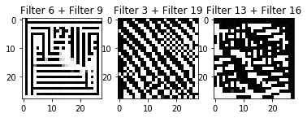

```python
plt.imshow(final_image[0].reshape(28,28), cmap='gray')
plt.figure(1, figsize=(20,10))
n_columns = 3
n_rows = 1
plt.subplot(n_rows, n_columns, 1)
plt.title('Filter 6 + Filter 9')
plt.imshow(final_image[0].reshape(28,28),cmap='gray')
plt.subplot(n_rows, n_columns, 2)
plt.title('Filter 3 + Filter 19')
plt.imshow(final_image[1].reshape(28,28),cmap='gray')
plt.subplot(n_rows, n_columns, 3)
plt.title('Filter 13 + Filter 16')
plt.imshow(final_image[2].reshape(28,28),cmap='gray')
```

All in all, we can conclude that the filters have interactions, when jointly optimized them, the effect on images is generating their pattern combined with similar styles.

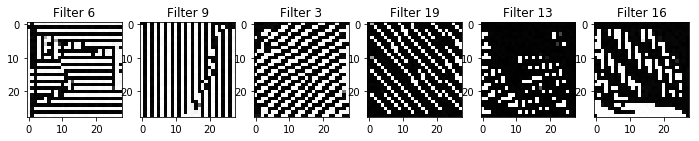

```python
plt.figure(1, figsize=(20,10))
n_columns = 10
n_rows = 4
chosenlist = [5,8,2,18,12,15]
for i in range(6):
    plt.subplot(n_rows, n_columns, i+1)
    plt.title('Filter ' + str(chosenlist[i]+1))
    plt.imshow(final_image_list1[chosenlist[i]].reshape(28,28),cmap='gray')
```

### Adding different weights for the combination

What I did in the above is jointly optimizing two filters equally-weighted to get a sense of how they interact. Here let's explore more to add different weights for the combination to see the images changing process.

```python
stepsize = 20000
sd = 0.1
mylambda = 0.2
learningrate = 0.01
pnorm = 1
weight = [0,0.1,0.2,0.3,0.4,0.5,0.6,0.7,0.8,0.9,1]

with tf.Graph().as_default() as new_graph:
    # Create the model

    x_image = tf.Variable(tf.truncated_normal((1,28,28,1),mean=0.5,stddev=sd))
    x_min = tf.reduce_min(x_image)
    x_max = tf.reduce_max(x_image)
    x_image_limit = (x_image - x_min) / (x_max - x_min)


    with tf.name_scope('conv1'):
        W_conv1 = tf.constant(par_values[0][1])
        b_conv1 = tf.constant(par_values[1][1])
        h_conv1 = tf.nn.relu(conv2d(x_image_limit, W_conv1) + b_conv1)

    with tf.name_scope('pool1'):
        h_pool1 = max_pool_2x2(h_conv1)

    with tf.name_scope('conv2'):
        W_conv2 = tf.constant(par_values[2][1])
        b_conv2 = tf.constant(par_values[3][1])
        h_conv2 = tf.nn.relu(conv2d(h_pool1, W_conv2) + b_conv2)

    with tf.name_scope('pool2'):
        h_pool2 = max_pool_2x2(h_conv2)

    with tf.name_scope('conv3'):
        W_conv3 = tf.constant(par_values[4][1])
        b_conv3 = tf.constant(par_values[5][1])
        h_conv3 = tf.nn.relu(conv2d(h_pool2, W_conv3) + b_conv3)

    with tf.name_scope('pool3'):
        h_pool3 = max_pool_2x2(h_conv3) ##  h_pool3 : 1 * 4 * 4 * 64


    with tf.name_scope('fc1'):
        W_fc1 = tf.constant(par_values[6][1])
        b_fc1 = tf.constant(par_values[7][1])

        h_pool3_flat = tf.reshape(h_pool3, [-1, 4*4*64])
        h_fc1 = tf.nn.relu(tf.matmul(h_pool3_flat, W_fc1) + b_fc1)

    with tf.name_scope('fc2'):
        W_fc2 = tf.constant(par_values[8][1])
        b_fc2 = tf.constant(par_values[9][1])

        y_conv = tf.matmul(h_fc1, W_fc2) + b_fc2

    with tf.name_scope('activation'):

        regularization = tf.norm((x_image_limit),ord=pnorm)
        filter_added = []
        for i in range(10):
            filter_added.append(-(weight[i] * tf.reduce_sum(h_conv1[:,:,:,5],[0,1,2])+(1-weight[i]) * tf.reduce_sum(h_conv1[:,:,:,8],[0,1,2])))

    with tf.name_scope('optimizer'):
        train_step = []
        for i in range(10):
            train_step.append(tf.train.AdamOptimizer(learningrate).minimize(filter_added[i] + mylambda * regularization))

    with tf.Session() as sess:
        final_image = []
        for j in range(10):
            sess.run(tf.global_variables_initializer())
            for i in range(stepsize):
                #if i%1000==0:
                #    print ('Image %d,step %d, activation: %g' % (j+1,i,sess.run(filter_added[j])))
                train_step[j].run()
            final_image.append(sess.run(x_image_limit))
        #print('Images ready!')
```

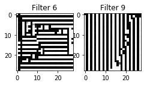

```python
plt.figure(1, figsize=(20,10))
n_columns = 10
n_rows = 1
chosenlist = [5,8]
for i in range(2):
    plt.subplot(n_rows, n_columns, i+1)
    plt.title('Filter ' + str(chosenlist[i]+1))
    plt.imshow(final_image_list1[chosenlist[i]].reshape(28,28),cmap='gray')
```

According to the above, we can see original images that maximumly activated those individual filters. The following showed the interaction between filters. When the weight for filter 6 is larger than 0.6, horizontal edges dominated, while when it's smaller than 0.4,vertical edges dominated. We saw what we expected, the more weights in favor of filter 6, the more amount of horizontal edges in the images.

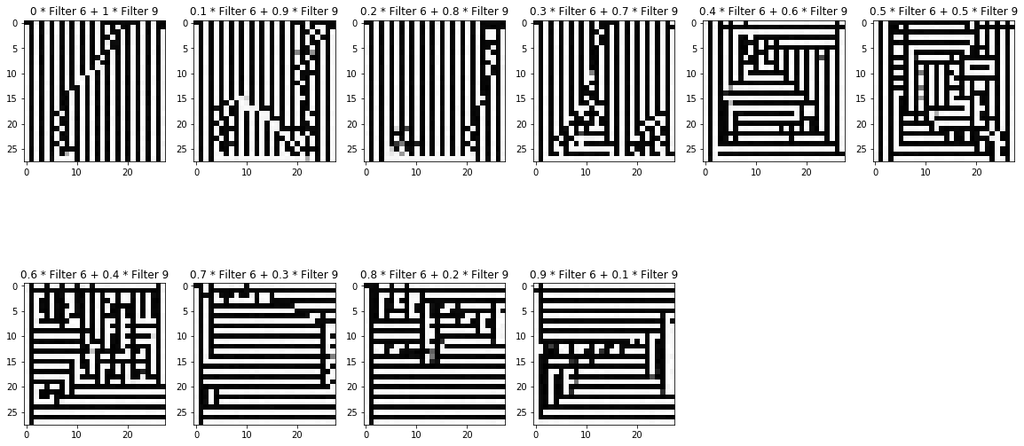

```python
plt.figure(1, figsize=(20,10))
n_columns = 6
n_rows = 2
weight = [0,0.1,0.2,0.3,0.4,0.5,0.6,0.7,0.8,0.9]
weight2 = [1,0.9,0.8,0.7,0.6,0.5,0.4,0.3,0.2,0.1]
for i in range(10):
    plt.subplot(n_rows, n_columns, i+1)
    plt.title(str(weight[i]) + ' * Filter 6 + ' + str(weight2[i]) + ' * Filter 9')
    plt.imshow(final_image[i].reshape(28,28),cmap='gray')
```

## 3. Experiment on SVHN

Based on the similar exploring framework, I changed my dataset to SVHN. I used its second format which is cropped digits, 32-by-32 images centered around a single number. The focus for this part,or say the problem I want to explore are, first, the label of MNIST and SVHN are both number digits, one is black and white, the other is of RGB colors, are there any similarities when do the feature visualization? Second, with color added, do those regularization methods have the same or different effect on the feature visualization? So I start to explore starting from training a network with same architecture.

### Load data

```python
import scipy as sp
import scipy.io as sio
from scipy.misc import *
from sklearn.preprocessing import OneHotEncoder
```

**Tips: My current fold does not include the data 'train_32x32.mat' and 'test_32x32.mat' since I want my project fold not be that large. If rerun needed, you could download the data from [here](http://ufldl.stanford.edu/housenumbers/) , and save it at the current path.**

```python
train_location = 'train_32x32.mat'
test_location = 'test_32x32.mat'

def load_train_data():
    train_dict = sio.loadmat(train_location)
    X = np.asarray(train_dict['X'])

    X_train = []
    for i in range(X.shape[3]):
        X_train.append(X[:,:,:,i])
    X_train = np.asarray(X_train)

    Y_train = train_dict['y']
    for i in range(len(Y_train)):
        if Y_train[i]%10 == 0:
            Y_train[i] = 0
    return (X_train,Y_train)

def load_test_data():
    test_dict = sio.loadmat(test_location)
    X = np.asarray(test_dict['X'])

    X_test = []
    for i in range(X.shape[3]):
        X_test.append(X[:,:,:,i])
    X_test = np.asarray(X_test)

    Y_test = test_dict['y']
    for i in range(len(Y_test)):
        if Y_test[i]%10 == 0:
            Y_test[i] = 0
    return (X_test,Y_test)
```

```python
X_train,Y_train = load_train_data()
X_test, Y_test = load_test_data()
```

```python
print(X_train.shape)
print(Y_train.shape)
```

```
(73257, 32, 32, 3)
(73257, 1)
```

```python
print(X_test.shape)
print(Y_test.shape)
```

```
(26032, 32, 32, 3)
(26032, 1)
```

### precoss the label with one-hot-encoding

```python
enc = OneHotEncoder()
enc.fit(Y_train)
Y_train=enc.transform(Y_train).toarray()
enc = OneHotEncoder()
enc.fit(Y_test)
Y_test=enc.transform(Y_test).toarray()
```

### design and train the model (still 3 layer cnn)

```python
def weight_variable(shape):
    """weight_variable generates a weight variable of a given shape."""
    return tf.get_variable("weights",dtype=tf.float32,shape=shape,initializer=tf.contrib.layers.xavier_initializer())
def bias_variable(shape):
    initial = tf.constant(0.0, shape=shape)
    return tf.Variable(initial)

def conv2d(x, W):
    return tf.nn.conv2d(x, W, strides=[1, 1, 1, 1], padding='SAME')

def max_pool_2x2(x):
    return tf.nn.max_pool(x, ksize=[1, 2, 2, 1],
                        strides=[1, 2, 2, 1], padding='SAME')
```

```python
def deepnn(x):

    x_image = x

    # First convolutional layer - maps one grayscale image to 32 feature maps.
    with tf.variable_scope('conv1'):
        W_conv1 = weight_variable([5, 5, 3, 32])
        b_conv1 = bias_variable([32])
        h_conv1 = tf.nn.relu(conv2d(x_image, W_conv1) + b_conv1) ## feature map size
                                                                 ## h_conv1: 1 * 32 * 32 * 32

      # Pooling layer - downsamples by 2X.
    with tf.variable_scope('pool1'):
        h_pool1 = max_pool_2x2(h_conv1)  ## 1 * 16 * 16 * 32

      # Second convolutional layer -- maps 32 feature maps to 64.
    with tf.variable_scope('conv2'):
        W_conv2 = weight_variable([5, 5, 32, 64])
        b_conv2 = bias_variable([64])
        h_conv2 = tf.nn.relu(conv2d(h_pool1, W_conv2) + b_conv2) ## h_conv2: 1 * 16* 16 * 64

      # Second pooling layer.
    with tf.variable_scope('pool2'):
        h_pool2 = max_pool_2x2(h_conv2)   ## h_pool2 : 1 * 8 * 8 *64


      # 3rd
    with tf.variable_scope('conv3'):
        W_conv3 = weight_variable([5, 5, 64, 64])
        b_conv3 = bias_variable([64])
        h_conv3 = tf.nn.relu(conv2d(h_pool2, W_conv3) + b_conv3)  ## h_conv3 : 1 * 8 * 8 * 64

      # 3rd
    with tf.variable_scope('pool3'):
        h_pool3 = max_pool_2x2(h_conv3) ##  h_pool3 : 1 * 4 * 4 * 64

      # Fully connected layer 1 -- after 2 round of downsampling, our 28x28 image
      # is down to 7x7x64 feature maps -- maps this to 1024 features.
    with tf.variable_scope('fc1'):
        W_fc1 = weight_variable([4 * 4 * 64, 1024])
        b_fc1 = bias_variable([1024])

        h_pool3_flat = tf.reshape(h_pool3, [-1, 4*4*64])
        h_fc1 = tf.nn.relu(tf.matmul(h_pool3_flat, W_fc1) + b_fc1)

      # Dropout - controls the complexity of the model, prevents co-adaptation of
      # features.
    with tf.variable_scope('dropout'):
        keep_prob = tf.placeholder(tf.float32)
        h_fc1_drop = tf.nn.dropout(h_fc1, keep_prob)

      # Map the 1024 features to 10 classes, one for each digit
    with tf.variable_scope('fc2'):
        W_fc2 = weight_variable([1024, 10])
        b_fc2 = bias_variable([10])

        y_conv = tf.matmul(h_fc1_drop, W_fc2) + b_fc2
    return y_conv, keep_prob
```

```python
def next_batch(num, data, labels):
    '''
    Return a total of `num` random samples and labels.
    '''
    idx = np.arange(0 , len(data))
    np.random.shuffle(idx)
    idx = idx[:num]
    data_shuffle = [data[i] for i in idx]
    labels_shuffle = [labels[i] for i in idx]

    return np.asarray(data_shuffle), np.asarray(labels_shuffle)
```

```python
# Create the model
x = tf.placeholder(tf.float32, [None, 32,32,3])

# Define loss and optimizer
y_ = tf.placeholder(tf.float32, [None, 10])

# Build the graph for the deep net
y_conv, keep_prob = deepnn(x)

with tf.name_scope('loss'):
    cross_entropy = tf.nn.softmax_cross_entropy_with_logits(labels=y_,
                                                            logits=y_conv)
    cross_entropy = tf.reduce_mean(cross_entropy)

with tf.name_scope('adam_optimizer'):
    train_step = tf.train.AdamOptimizer(1e-4).minimize(cross_entropy)

with tf.name_scope('accuracy'):
    correct_prediction = tf.equal(tf.argmax(y_conv, 1), tf.argmax(y_, 1))
    correct_prediction = tf.cast(correct_prediction, tf.float32)
    accuracy = tf.reduce_mean(correct_prediction)

graph_location = tempfile.mkdtemp()
#print('Saving graph to: %s' % graph_location)
train_writer = tf.summary.FileWriter(graph_location)
train_writer.add_graph(tf.get_default_graph())

with tf.Session() as sess:
    sess.run(tf.global_variables_initializer())
    for i in range(10000):
        batch = next_batch(128,X_train,Y_train)
        if i % 100 == 0:
            train_accuracy = accuracy.eval(feed_dict={
            x: batch[0], y_: batch[1], keep_prob: 1.0})
            #print('step %d, training accuracy %g' % (i, train_accuracy))
        train_step.run(feed_dict={x: batch[0], y_: batch[1], keep_prob: 0.5})
    var = [v for v in tf.trainable_variables()]
    par_values = [(v,sess.run(v)) for v in var]

    #print('test accuracy %g' % accuracy.eval(feed_dict={
    #    x: X_test, y_: Y_test, keep_prob: 1.0}))
```

```python
stepsize = 10000
learning_rate = 0.01
sd = 0.1
# We try not adding regularization term first
#mylambda = 0.2
#pnorm = 1

with tf.Graph().as_default() as new_graph:

    x_image = tf.Variable(tf.truncated_normal((1,32,32,3),mean=0.5,stddev=sd))
    x_min = tf.reduce_min(x_image)
    x_max = tf.reduce_max(x_image)
    x_image_limit = (x_image - x_min) / (x_max - x_min)

    with tf.name_scope('conv1'):
        W_conv1 = tf.constant(par_values[0][1])
        b_conv1 = tf.constant(par_values[1][1])
        h_conv1 = tf.nn.relu(conv2d(x_image_limit, W_conv1) + b_conv1)


    with tf.name_scope('pool1'):
        h_pool1 = max_pool_2x2(h_conv1)

    with tf.name_scope('conv2'):
        W_conv2 = tf.constant(par_values[2][1])
        b_conv2 = tf.constant(par_values[3][1])
        h_conv2 = tf.nn.relu(conv2d(h_pool1, W_conv2) + b_conv2)

    with tf.name_scope('pool2'):
        h_pool2 = max_pool_2x2(h_conv2)

    with tf.name_scope('conv3'):
        W_conv3 = tf.constant(par_values[4][1])
        b_conv3 = tf.constant(par_values[5][1])
        h_conv3 = tf.nn.relu(conv2d(h_pool2, W_conv3) + b_conv3)

    with tf.name_scope('pool3'):
        h_pool3 = max_pool_2x2(h_conv3)

    with tf.name_scope('fc1'):
        W_fc1 = tf.constant(par_values[6][1])
        b_fc1 = tf.constant(par_values[7][1])

        h_pool3_flat = tf.reshape(h_pool3, [-1, 4*4*64])
        h_fc1 = tf.nn.relu(tf.matmul(h_pool3_flat, W_fc1) + b_fc1)

    with tf.name_scope('fc2'):
        W_fc2 = tf.constant(par_values[8][1])
        b_fc2 = tf.constant(par_values[9][1])

        y_conv = tf.matmul(h_fc1, W_fc2) + b_fc2

    with tf.name_scope('activation'):
        filter_list1 = []
        filter_list2 = []
        filter_list3 = []
        filter_list4 = []
        #regularization = tf.norm((x_image_limit),ord=pnorm)   ## L2 - norm
        for i in range(10):  ## 32 filters in total
            filter_list1.append(-tf.reduce_sum(h_conv1[:,:,:,i],[0,1,2])) #h_conv1 shape: 1 * 28 * 28 * 32
        for i in range(10):  ## 64 filters in total
            filter_list2.append(-tf.reduce_sum(h_conv2[:,:,:,i],[0,1,2])) #h_conv2 shape: 1 * 14 * 14 * 64
        for i in range(10):  ## 64 filters in total
            filter_list3.append(-tf.reduce_sum(h_conv3[:,:,:,i],[0,1,2])) #h_conv3 shape: 1 * 7 * 7 * 64
        for i in range(10):  ## 64 filters in total
            filter_list4.append(-y_conv[0,i])


    with tf.name_scope('optimizer'):
        train_step_list1 = []
        train_step_list2 = []
        train_step_list3 = []
        train_step_list4 = []
        for i in range(10):
            train_step_list1.append(tf.train.AdamOptimizer(learning_rate).minimize(filter_list1[i]
                                                                                   #+ mylambda * regularization
                                                                                  ))
        for i in range(10):
            train_step_list2.append(tf.train.AdamOptimizer(learning_rate).minimize(filter_list2[i]
                                                                                   #+ mylambda * regularization
                                                                                  ))
        for i in range(10):
            train_step_list3.append(tf.train.AdamOptimizer(learning_rate).minimize(filter_list3[i]
                                                                                   #+ mylambda * regularization
                                                                                  ))
        for i in range(10):
            train_step_list4.append(tf.train.AdamOptimizer(learning_rate).minimize(filter_list4[i]
                                                                                   #+ mylambda * regularization
                                                                                  ))

    with tf.Session() as sess:
        final_image_list1 = []
        final_image_list2 = []
        final_image_list3 = []
        final_image_list4 = []
        for j in range(10):
            sess.run(tf.global_variables_initializer())
            for i in range(stepsize):
                #if i%1000==0:
                #     print('layer1,filter %d,step %d, activation: %g' % (j,i, sess.run(filter_list1[j])))
                train_step_list1[j].run()
            final_image_list1.append(sess.run(x_image_limit))
        #print('layer1 image ready!')

        for j in range(10):
            sess.run(tf.global_variables_initializer())
            for i in range(stepsize):
                #if i%1000==0:
                #    print('layer2,filter %d,step %d, activation: %g' % (j,i, sess.run(filter_list2[j])))
                train_step_list2[j].run()
            final_image_list2.append(sess.run(x_image_limit))
        #print('layer2 image ready!')

        for j in range(10):
            sess.run(tf.global_variables_initializer())
            for i in range(stepsize):
                #if i%1000==0:
                #    print('layer3,filter %d,step %d, activation: %g' % (j,i, sess.run(filter_list3[j])))
                train_step_list3[j].run()
            final_image_list3.append(sess.run(x_image_limit))
        #print('layer3 image ready!')


        for j in range(10):
            sess.run(tf.global_variables_initializer())
            for i in range(stepsize):
                #if i%1000==0:
                #    print('output layer,filter %d,step %d, activation: %g' % (j,i, sess.run(filter_list4[j])))
                train_step_list4[j].run()
            final_image_list4.append(sess.run(x_image_limit))
        #print('output layer image ready!')
```

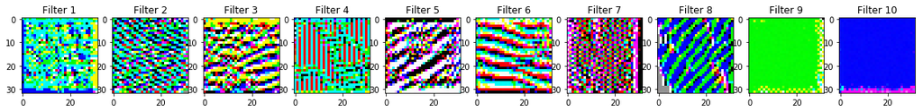

```python
plt.figure(1, figsize=(20,10))
n_columns = 10
n_rows = 1
for i in range(10):
    plt.subplot(n_rows, n_columns, i+1)
    plt.title('Filter ' + str(i+1))
    plt.imshow(final_image_list1[i].reshape(32,32,3))
```

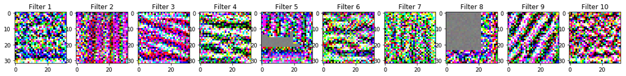

```python
plt.figure(1, figsize=(20,10))
n_columns = 10
n_rows = 1
for i in range(10):
    plt.subplot(n_rows, n_columns, i+1)
    plt.title('Filter ' + str(i+1))
    plt.imshow(final_image_list2[i].reshape(32,32,3))
```

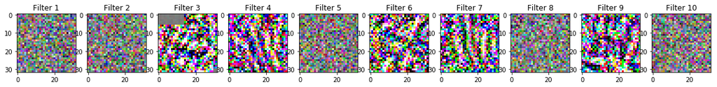

```python
plt.figure(1, figsize=(20,10))
n_columns = 10
n_rows = 1
for i in range(10):
    plt.subplot(n_rows, n_columns, i+1)
    plt.title('Filter ' + str(i+1))
    plt.imshow(final_image_list3[i].reshape(32,32,3))
```

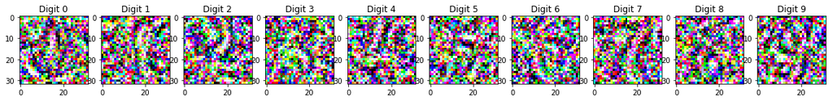

```python
plt.figure(1, figsize=(20,10))
n_columns = 10
n_rows = 1
for i in range(10):
    plt.subplot(n_rows, n_columns, i+1)
    plt.title('Digit ' + str(i))
    plt.imshow(final_image_list4[i].reshape(32,32,3))
```

### 3.1 improving attempt 1 (Adding regularization term during feature visualization)

From the experience of exploring MNIST dataset, I found the main problem of doing feature visualization is high frequency noise. Changing parameters of the initializing part does not work well, so here I directly try regularization to improve. The code added for adding regularization term is similar to the code added for MNIST, so here, I do not show the code but only the images I tried getting.

I tried L1 regularization with lambda = {0.001,0.01,0.1}, and shrinked the optimal range to (0.001,0.01).

#### Final output layer with L1-norm & lambda = 0.001

[figure not shown]

#### Final output layer with L1-norm & lambda = 0.01

[figure not shown]

#### Final output layer with L1-norm & lambda = 0.1

[figure not shown]

Then I tried 0.002 and 0.005. I found using L1 regularization with lambda being 0.005 gained the better images regarding to the recognizability of the digits in the final layer.

#### Final output layer with L1-norm & lambda = 0.002

[figure not shown]

#### Final output layer with L1-norm & lambda = 0.005

[figure not shown]

The images of each layer are showed as the following,with L1-norm & lambda = 0.005. The first two layers are similar with some edges and texture, for the output layer, some more 'digit-like' pattern can be detected.

#### 1st convolutional layer with L1-norm & lambda = 0.005

[figure not shown]

#### 2nd convolutional layer with L1-norm & lambda = 0.005

[figure not shown]

#### 3rd convolutional layer with L1-norm & lambda = 0.005

[figure not shown]

#### Final output layer with L1-norm & lambda = 0.005

[figure not shown]

I also tried L2 regularization with lambda = {0.001,0.01,0.1}, and shrinked the optimal range to (0.01,0.1), then I tried 0.05,0.07,0.2 and found using L2 regularization with lambda being 0.1 gained the better images as the following, but it's seemed that L1 is better.

#### 1st convolutional layer with L2-norm & lambda = 0.1

[figure not shown]

#### 2nd convolutional layer with L2-norm & lambda = 0.1

[figure not shown]

#### 3rd convolutional layer with L2-norm & lambda = 0.1

[figure not shown]

#### Final output layer with L2-norm & lambda = 0.1

[figure not shown]

### 3.2 improving attempt 2 (Modify image after each optimization: Decay & Gaussian blur & Median Filter)

I then did the same thing, tried decay and gaussian blur to avoid high frequency noise.

I tried gaussian radius with radius being {0.1,0.3,0.5,0.7} and found the radius did not make big difference to the images. Here just show the images with gaussian blur whose radius being 0.3. Here I also tried decay_rate = {0.9,0.99,0.999,0.9999} and the following shows the better images with decay rate with 0.999. We could see that the decay and gaussian blur seems to have similar effect here. And it's reasonable considering the principle, since they can both be used to force the pixels get close to mean. When combining them together, the effect seems to be improved.

#### Final output layer with blur whose radius being 0.3

[figure not shown]

#### Final output layer with decay rate 0.999

[figure not shown]

#### Final output layer with blur whose radius being 0.3 and decay rate 0.999

[figure not shown]

Recall the exploration on MNIST dataset, the decay did not work, while it works better in SVHN dataset than in the MNIST.I guess the reason is that decay avoids bright pixels with very high values in red, green or blue here, so we did not see the complex but messy pattern with different color full of the images, but the function got weaken in the dataset without color.

## 4. Summary

This project explored how neural network work by doing feature visualization, more specific, I tried finding the input images that maximize certain layers' activation of a neural network and make it more recognizable by optimizing the process. Considering the computational difficulties, I tested on a 3 layer convolutional neural network using the MNIST and SVHN dataset.

The images that maximumly activated lower level layers demonstrate great and clear pattern for both dataset, like edges at different direction, horizontal, vertical or diagonal, and they also have different sizes, like wide stripe and narrow ones. This images could be produced without any optimization like adding regularization term.

**The images that maximumly activated 1st layer of net on MNIST dataset**

[figure not shown]

**The images that maximumly activated 1st layer of net on SVHN dataset**

[figure not shown]

Another thing I did for the first layer is to verify the interaction between neurons. As the google post suggested,besides individual neuron as a way to understand neural nets, we can also explore the combinations of neurons working together to represent images in neural networks. Individual neurons are the basis directions of activation space, and it is not clear that these should be any more special than any other direction. So here I tried exploring interaction between filters(neurons) by jointly maximizing the activation of two filters, with weight changing.

**The original images that maximumly activated filter 6 and 9 in the 1st layer**

[figure not shown]

**The images that jointly maximumly activated filter 6 and 9 with different weights**

[figure not shown]

According to the above, we can conclude that the filters have interactions, when jointly optimized them, the effect on images is generating their pattern combined with similar styles. The weights for optimizing each filter are mainly reflected on the area of two patterns.

While I used the same method for visualizing intermediate feature layers, directly visualizing the corresponding filters in that convolution layer, does not work for any layer beyond the first one. No more complex texture founded but the noise pattern appeared in some of the filter. Optimizing by add regularization term or adjust the initializing images does not gain a good feedback as well. I've read a paper, it mentioned we could feed activations of the intermediate layers of CNN to a deconvolution network, so as to map the activations to the pixel space. The deconvolutional network can be thought of as applying the reverse steps of filtering and pooling, in order to map the features back to the pixel space<sup>[14]</sup>. I tried but failed due to some coding problem, but this can be a future direction which worth a try.

For the output layer, I tried some regularization term or adjust the images like clipping, blurring or use decay at each gradient step. Some of the images produced could be recognized as some digits.It shows that the neural network had clearly learned to recognize the general shape of some of the digits, while it was impossible to see how it recognized other digits, since for some digits, it's still unrecognizable.

**The images that maximumly activated output layer of net on MNIST dataset**

[figure not shown]

**The images that maximumly activated output layer of net on SVHN dataset**

[figure not shown]

The reason is perhaps that the network tries to recognize all of the digits simultaneously, and it has found that certain pixels often determine whether the image shows one digit or another. So the neural network has learned to differentiate those pixels that it has found to be important, but not the underlying curves and shapes of the digits. Actually, it's quite similar way in which human recognizes the digits. Another possibility is that the dataset contains mis-classified digits which may confuse the neural network during training. I've checked by printing some of the data and found some of the digits in the dataset are very hard to read even for humans, and this may cause the neural network to become distorted and trying to recognize strange artifacts in the images.Also, I found that these images vary each time I run the code, so it has some randomness.

### Further direction

For this project, I only explored the images that maximize the features of the convolutional layers and the final layers, but not fully-connected layer, this could also be a further direction. I could also try adding more layers(convolutional layers or fully-connected layers) and find the input images that maximize their features, so that I could check whether it's useful to add more convolutional layers than three. Actually I tried 2 layers and 3 layers seems to be slightly better.

If there is less computational difficulties, I would explore in those further directions. I could plot the images for all features in each layer instead of just the first 10 features, and see how many of them appear to be unused or redundant. And also check what happens if lowering the number of features in that layer and train the network again, does it still perform just as well.

For the optimization part, there are large space to improve. Like I mentioned, there are some ways to try to improve intermediate layers' feature visualizing, like feed activations of the intermediate layers of CNN to a deconvolution network, so as to map the activations to the pixel space. For the three families regularization,frequency penalization,transformation robustness and learned priors, there are a lot of more work to try.

### Experience I learned

First I learned is the importance of GPU. Since I'm doing the project myself, waiting for the code to see the results is so tiring and postponed the whole process. Second, there is a long way between understand a paper's idea and know how to implement it. Coding them in the architecture of Tensorflow also added more difficulties. But at the beginning, this is what I did not expect, so I spent a lot of time in searching for materials and reading paper, and have no enough time to implement what I want, so the thing I implemented actually is so limited. This is also experience gained, that is plan time reasonably.

All in all, reading paper and trying implement as well as optimize the feature visualization process are all interesting. Since every change I made in the programming or parameters can be immediately reflected in the images I produced, I was always inspired by a little improvement of the images(become more recognizable). Moreover, Some of my expectations are verified undoubtedly, while other what I thought the images should be just did not happen, exploring the reason and explanation is also interesting exploring. Therefore, I would say it's a so meaningful project.

## Reference

[1] http://ufldl.stanford.edu/housenumbers/

[2] https://distill.pub/2017/feature-visualization/

[3] Visualizing higher-layer features of a deep network [[PDF]](https://www.researchgate.net/publication/265022827_Visualizing_Higher-Layer_Features_of_a_Deep_Network) Erhan, D., Bengio, Y., Courville, A. and Vincent, P., 2009. University of Montreal, Vol 1341, pp. 3.

[4] Intriguing properties of neural networks [[PDF]](https://arxiv.org/pdf/1312.6199.pdf) Szegedy, C., Zaremba, W., Sutskever, I., Bruna, J., Erhan, D., Goodfellow, I. and Fergus, R., 2013. arXiv preprint arXiv:1312.6199.

[5] Understanding deep image representations by inverting them [[PDF]](https://arxiv.org/pdf/1412.0035v1.pdf) Mahendran, A. and Vedaldi, A., 2015. Proceedings of the IEEE Conference on Computer Vision and Pattern Recognition, pp. 5188--5196. DOI: 10.1109/cvpr.2015.7299155.

[6] Deep neural networks are easily fooled: High confidence predictions for unrecognizable images. [[PDF]](https://arxiv.org/pdf/1412.1897.pdf) Nguyen, A., Yosinski, J. and Clune, J., 2015. Proceedings of the IEEE Conference on Computer Vision and Pattern Recognition, pp. 427--436. DOI: 10.1109/cvpr.2015.7298640.

[7] https://mtyka.github.io/deepdream/2016/02/05/bilateral-class-vis.html

[8] Fast Bilateral Filtering for the Display of High-Dynamic-Range Images. [[PDF]](http://tka4.org/materials/lib/Articles-Books/Filters/Bilateral/p257-durand.pdf) Fr´edo Durand and Julie Dorsey.

[9] Deep inside convolutional networks: Visualising image classification models and saliency maps [[PDF]](https://arxiv.org/pdf/1312.6034.pdf) Simonyan, K., Vedaldi, A. and Zisserman, A., 2013. arXiv preprint arXiv:1312.6034.

[10] Plug/play generative networks: Conditional iterative generation of images in latent space [[PDF]](https://arxiv.org/pdf/1612.00005.pdf) Nguyen, A., Yosinski, J., Bengio, Y., Dosovitskiy, A. and Clune, J., 2016. arXiv preprint arXiv:1612.00005.

[11] https://github.com/tensorflow/tensorflow/blob/r1.4/tensorflow/examples/tutorials/mnist/mnist_deep.py

[12] https://en.wikipedia.org/wiki/Gaussian_blur

[13] http://dev.theomader.com/gaussian-kernel-calculator/

[14] Visualizing and Understanding Convolutional Networks [[PDF]](https://cs.nyu.edu/~fergus/papers/zeilerECCV2014.pdf) Matthew D. Zeiler and Rob Fergus